# pmbc

Sobur Ali

2024-07-02

Import packages

```r
library(Seurat)
library(SeuratObject)
library(devtools)
library(patchwork)
library(tidyverse)
```

load 10x data

```r
pbmc.data <- Read10X("data/hg19/")
```

Create a SeuratObject with the data

```r
pbmc.obj <- CreateSeuratObject(counts = pbmc.data, project = "pbmc3k", min.cells = 3, min.features = 200)
```

See the data

```r
head(pbmc.obj@meta.data, 5)
```

```
##                  orig.ident nCount_RNA nFeature_RNA
## AAACATACAACCAC-1     pbmc3k       2419          779
## AAACATTGAGCTAC-1     pbmc3k       4903         1352
## AAACATTGATCAGC-1     pbmc3k       3147         1129
## AAACCGTGCTTCCG-1     pbmc3k       2639          960
## AAACCGTGTATGCG-1     pbmc3k        980          521
```

#QC and selecting cells Calculate the percentage of mitocondrial genes

```r
pbmc.obj[["percent.mt"]] <- PercentageFeatureSet(pbmc.obj, pattern = "^MT-")
```

Visualize QC metrics as a violin plot

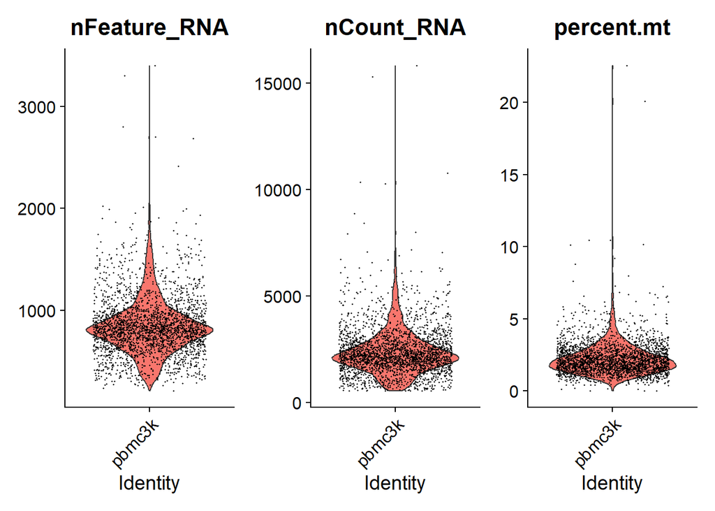

```r
VlnPlot(pbmc.obj, features = c("nFeature_RNA", "nCount_RNA", "percent.mt"), ncol = 3)
```

FeatureScatter is typically used to visualize feature-feature relationships, but can be used for anything calculated by the object, i.e. columns in object metadata, PC scores etc.

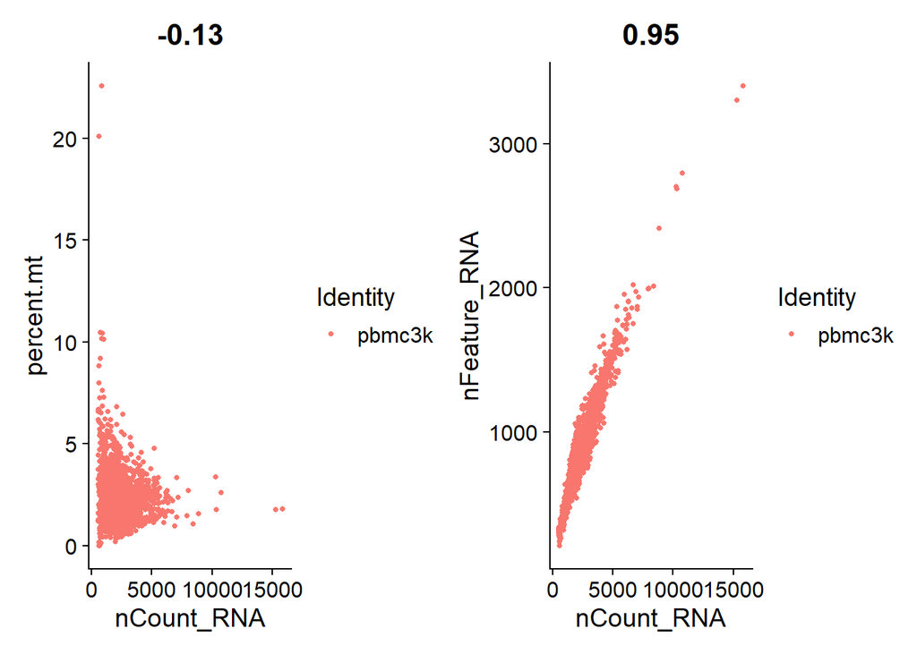

```r
scplot1 <- FeatureScatter(pbmc.obj, feature1 = "nCount_RNA", feature2 = "percent.mt")
scplot2 <- FeatureScatter(pbmc.obj, feature1 = "nCount_RNA", feature2 = "nFeature_RNA")
scplot1 + scplot2
```

Filter out the low quality data

```r
pbmc.obj <- subset(pbmc.obj, subset = nFeature_RNA > 200 & nFeature_RNA < 2500 & percent.mt < 5)
```

#Normalizing the data A global-scaling normalization method “LogNormalize” that normalizes the feature expression measurements for each cell by the total expression, multiplies this by a scale factor (10,000 by default), and log-transforms the result.

```r
pbmc.obj <- NormalizeData(pbmc.obj, normalization.method = "LogNormalize", scale.factor = 10000)
```

```
## Normalizing layer: counts
```

```r
#pbmc.obj <- NormalizeData(pbmc.obj)
```

#Identification of highly variable features (feature selection) We next calculate a subset of features that exhibit high cell-to-cell variation in the dataset (i.e, they are highly expressed in some cells, and lowly expressed in others).

```r
pbmc.obj <- FindVariableFeatures(pbmc.obj, selection.method = "vst", nfeatures = 2000)
```

```
## Finding variable features for layer counts
```

# Identify the 10 most highly variable genes

```r
top10_gene <- head(VariableFeatures(pbmc.obj), 10)
```

```
## When using repel, set xnudge and ynudge to 0 for optimal results
```

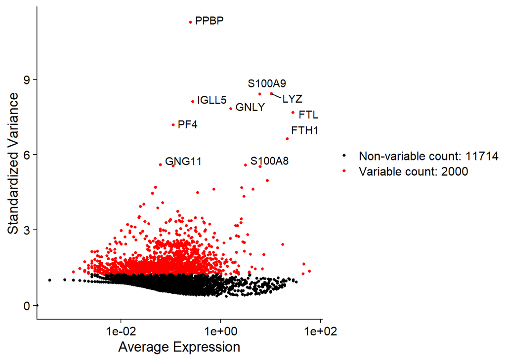

```r
# plot variable features with and without labels
plot1 <- VariableFeaturePlot(pbmc.obj)
LabelPoints(plot = plot1, points = top10_gene, repel = TRUE)
```

#Scaling the data Next, we apply a linear transformation (‘scaling’) that is a standard pre-processing step prior to dimensional reduction techniques like PCA. The ScaleData() function:

Shifts the expression of each gene, so that the mean expression across cells is 0 Scales the expression of each gene, so that the variance across cells is 1 This step gives equal weight in downstream analyses, so that highly-expressed genes do not dominate The results of this are stored in pbmc[[“RNA”]]$scale.data By default, only variable features are scaled. You can specify the features argument to scale additional features

```r
all.genes <- rownames(pbmc.obj)
```

Scaling data

```r
pbmc.obj <- ScaleData(pbmc.obj, features = all.genes)
```

##Cluster the cells

```r
pbmc.obj <- RunPCA(pbmc.obj, features = VariableFeatures(object = pbmc.obj))
```

```
## PC_ 1
## Positive:  CST3, TYROBP, LST1, AIF1, FTL, FTH1, LYZ, FCN1, S100A9, TYMP
##     FCER1G, CFD, LGALS1, S100A8, CTSS, LGALS2, SERPINA1, IFITM3, SPI1, CFP
##     PSAP, IFI30, SAT1, COTL1, S100A11, NPC2, GRN, LGALS3, GSTP1, PYCARD
## Negative:  MALAT1, LTB, IL32, IL7R, CD2, B2M, ACAP1, CD27, STK17A, CTSW
##     CD247, GIMAP5, AQP3, CCL5, SELL, TRAF3IP3, GZMA, MAL, CST7, ITM2A
##     MYC, GIMAP7, HOPX, BEX2, LDLRAP1, GZMK, ETS1, ZAP70, TNFAIP8, RIC3
## PC_ 2
## Positive:  CD79A, MS4A1, TCL1A, HLA-DQA1, HLA-DQB1, HLA-DRA, LINC00926, CD79B, HLA-DRB1, CD74
##     HLA-DMA, HLA-DPB1, HLA-DQA2, CD37, HLA-DRB5, HLA-DMB, HLA-DPA1, FCRLA, HVCN1, LTB
##     BLNK, P2RX5, IGLL5, IRF8, SWAP70, ARHGAP24, FCGR2B, SMIM14, PPP1R14A, C16orf74
## Negative:  NKG7, PRF1, CST7, GZMB, GZMA, FGFBP2, CTSW, GNLY, B2M, SPON2
##     CCL4, GZMH, FCGR3A, CCL5, CD247, XCL2, CLIC3, AKR1C3, SRGN, HOPX
##     TTC38, APMAP, CTSC, S100A4, IGFBP7, ANXA1, ID2, IL32, XCL1, RHOC
## PC_ 3
## Positive:  HLA-DQA1, CD79A, CD79B, HLA-DQB1, HLA-DPB1, HLA-DPA1, CD74, MS4A1, HLA-DRB1, HLA-DRA
##     HLA-DRB5, HLA-DQA2, TCL1A, LINC00926, HLA-DMB, HLA-DMA, CD37, HVCN1, FCRLA, IRF8
##     PLAC8, BLNK, MALAT1, SMIM14, PLD4, P2RX5, IGLL5, LAT2, SWAP70, FCGR2B
## Negative:  PPBP, PF4, SDPR, SPARC, GNG11, NRGN, GP9, RGS18, TUBB1, CLU
##     HIST1H2AC, AP001189.4, ITGA2B, CD9, TMEM40, PTCRA, CA2, ACRBP, MMD, TREML1
##     NGFRAP1, F13A1, SEPT5, RUFY1, TSC22D1, MPP1, CMTM5, RP11-367G6.3, MYL9, GP1BA
## PC_ 4
## Positive:  HLA-DQA1, CD79B, CD79A, MS4A1, HLA-DQB1, CD74, HIST1H2AC, HLA-DPB1, PF4, SDPR
##     TCL1A, HLA-DRB1, HLA-DPA1, HLA-DQA2, PPBP, HLA-DRA, LINC00926, GNG11, SPARC, HLA-DRB5
##     GP9, AP001189.4, CA2, PTCRA, CD9, NRGN, RGS18, CLU, TUBB1, GZMB
## Negative:  VIM, IL7R, S100A6, IL32, S100A8, S100A4, GIMAP7, S100A10, S100A9, MAL
##     AQP3, CD2, CD14, FYB, LGALS2, GIMAP4, ANXA1, CD27, FCN1, RBP7
##     LYZ, S100A11, GIMAP5, MS4A6A, S100A12, FOLR3, TRABD2A, AIF1, IL8, IFI6
## PC_ 5
## Positive:  GZMB, NKG7, S100A8, FGFBP2, GNLY, CCL4, CST7, PRF1, GZMA, SPON2
##     GZMH, S100A9, LGALS2, CCL3, CTSW, XCL2, CD14, CLIC3, S100A12, RBP7
##     CCL5, MS4A6A, GSTP1, FOLR3, IGFBP7, TYROBP, TTC38, AKR1C3, XCL1, HOPX
## Negative:  LTB, IL7R, CKB, VIM, MS4A7, AQP3, CYTIP, RP11-290F20.3, SIGLEC10, HMOX1
##     LILRB2, PTGES3, MAL, CD27, HN1, CD2, GDI2, CORO1B, ANXA5, TUBA1B
##     FAM110A, ATP1A1, TRADD, PPA1, CCDC109B, ABRACL, CTD-2006K23.1, WARS, VMO1, FYB
```

Create a ElbowPlot to see the PC

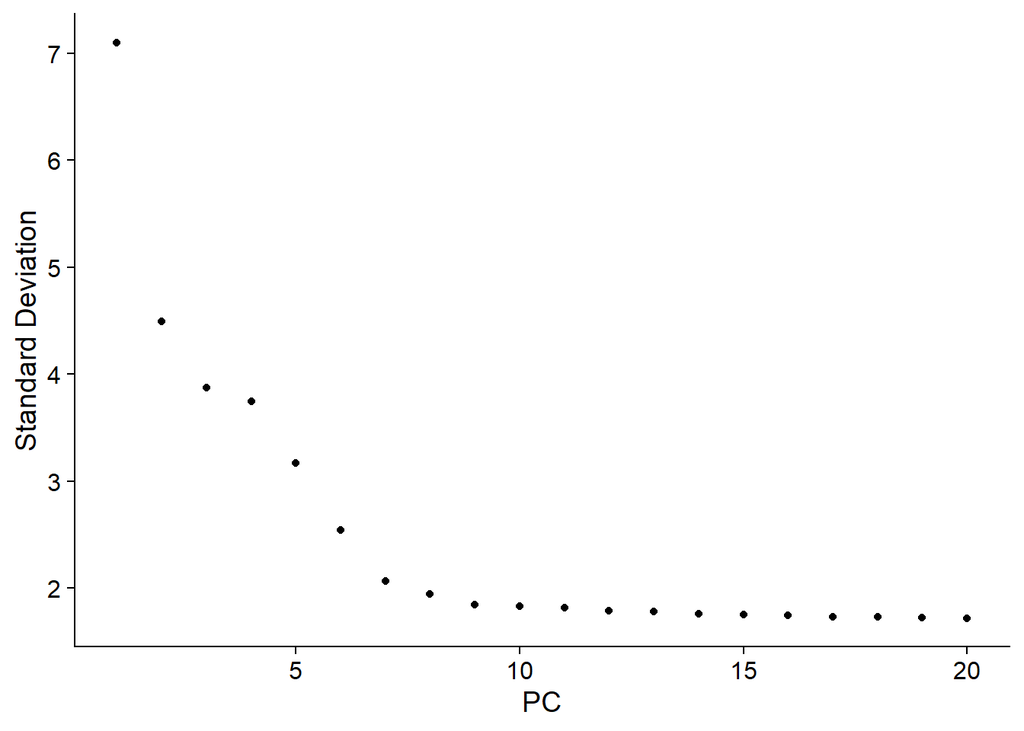

```r
ElbowPlot(pbmc.obj)
```

Neighhors finding

```r
pbmc.obj <- FindNeighbors(pbmc.obj, dims = 1:10)
```

Fluster finding

```r
pbmc.obj <- FindClusters(pbmc.obj, resolution = 0.5)
```

```
## Modularity Optimizer version 1.3.0 by Ludo Waltman and Nees Jan van Eck
##
## Number of nodes: 2638
## Number of edges: 95927
##
## Running Louvain algorithm...
## Maximum modularity in 10 random starts: 0.8728
## Number of communities: 9
## Elapsed time: 0 seconds
```

Run non-linear dimensional resuction UMAP

```r
pbmc.obj <- RunUMAP(pbmc.obj, dims = 1:10)
```

Create the cluster

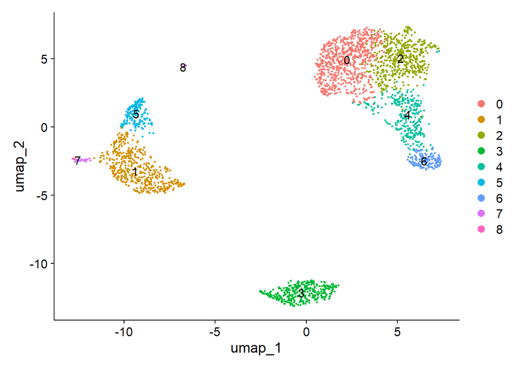

```r
DimPlot(pbmc.obj, reduction = "umap", label = TRUE)
```

#Finding differentially expressed features (cluster biomarkers)

find all markers of cluster 0

```r
cluster0.markers <- FindMarkers(pbmc.obj, ident.1 = 0)
```

[output not shown]

```r
head(cluster0.markers, n = 5)
```

```
##               p_val avg_log2FC pct.1 pct.2     p_val_adj
## RPS12 1.273332e-143  0.7387061 1.000 0.991 1.746248e-139
## RPS6  6.817653e-143  0.6934523 1.000 0.995 9.349729e-139
## RPS27 4.661810e-141  0.7372604 0.999 0.992 6.393206e-137
## RPL32 8.158412e-138  0.6266075 0.999 0.995 1.118845e-133
## RPS14 5.177478e-130  0.6336957 1.000 0.994 7.100394e-126
```

Violit plot of listed genes to see the expression in each cluster

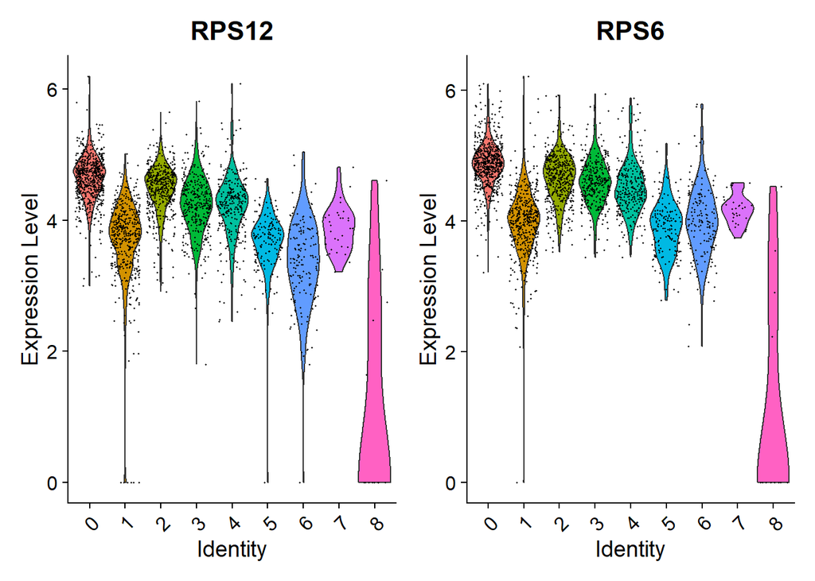

```r
VlnPlot(pbmc.obj, features = c("RPS12", "RPS6"))
```

Find marker genes in cluster 3

```r
cluster3.markers <- FindMarkers(pbmc.obj, ident.1 = 3)
head(cluster3.markers, n = 5)
```

```
##                   p_val avg_log2FC pct.1 pct.2     p_val_adj
## CD79A      0.000000e+00   6.911221 0.936 0.041  0.000000e+00
## MS4A1      0.000000e+00   5.718520 0.855 0.053  0.000000e+00
## CD79B     2.655974e-274   4.636747 0.916 0.142 3.642403e-270
## LINC00926 2.397625e-272   7.379757 0.564 0.009 3.288103e-268
## TCL1A     9.481783e-271   6.688051 0.622 0.022 1.300332e-266
```

Violin plot of selected genes

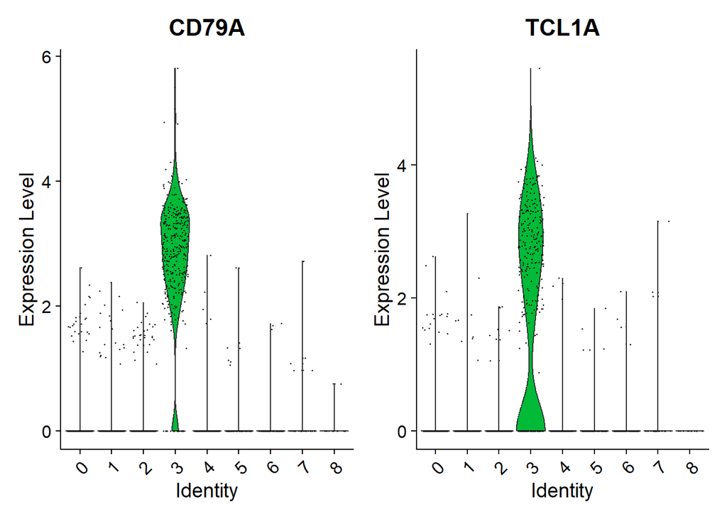

```r
VlnPlot(pbmc.obj, features = c("CD79A", "TCL1A"))
```

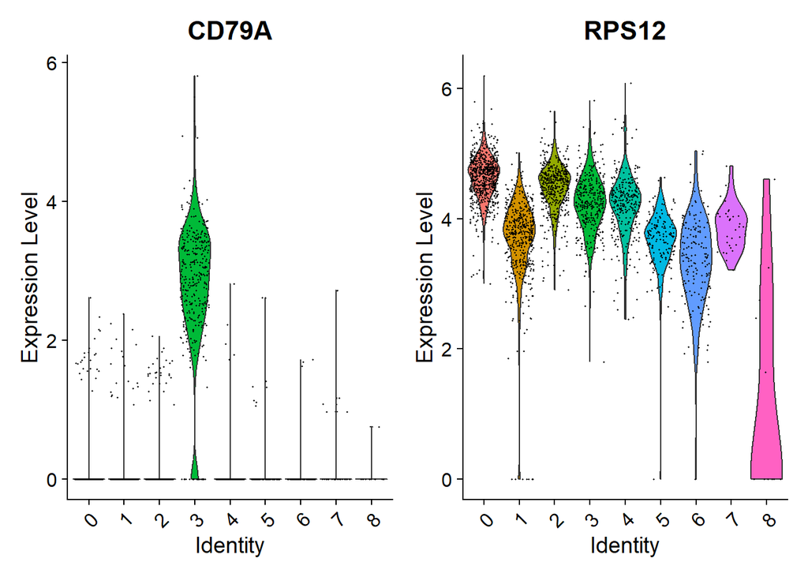

```r
VlnPlot(pbmc.obj, features = c("CD79A", "RPS12"))
```

find markers for every cluster compared to all remaining cells, report only the positiveones

```r
pbmc.markers <- FindAllMarkers(pbmc.obj, only.pos = TRUE)
pbmc.markers %>%
    group_by(cluster) %>%
    dplyr::filter(avg_log2FC > 1)
```

```
## # A tibble: 7,019 × 7
## # Groups:   cluster [9]
##        p_val avg_log2FC pct.1 pct.2 p_val_adj cluster gene
##        <dbl>      <dbl> <dbl> <dbl>     <dbl> <fct>   <chr>
##  1 3.75e-112       1.21 0.912 0.592 5.14e-108 0       LDHB
##  2 9.57e- 88       2.40 0.447 0.108 1.31e- 83 0       CCR7
##  3 1.15e- 76       1.06 0.845 0.406 1.58e- 72 0       CD3D
##  4 1.12e- 54       1.04 0.731 0.4   1.54e- 50 0       CD3E
##  5 1.35e- 51       2.14 0.342 0.103 1.86e- 47 0       LEF1
##  6 1.94e- 47       1.20 0.629 0.359 2.66e- 43 0       NOSIP
##  7 2.81e- 44       1.53 0.443 0.185 3.85e- 40 0       PIK3IP1
##  8 6.27e- 43       1.99 0.33  0.112 8.60e- 39 0       PRKCQ-AS1
##  9 1.16e- 40       2.70 0.2   0.04  1.59e- 36 0       FHIT
## 10 1.34e- 34       1.96 0.268 0.087 1.84e- 30 0       MAL
## # ℹ 7,009 more rows
```

Feature plot of multiple selected marker gene

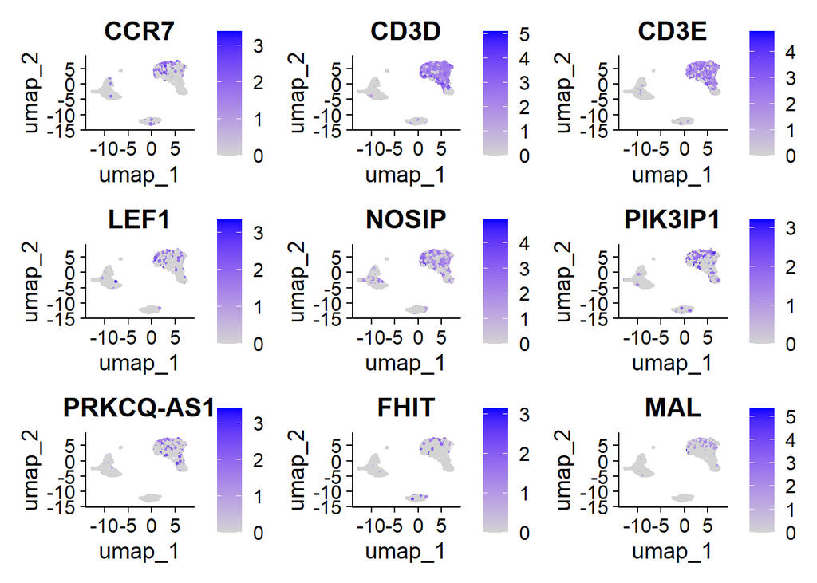

```r
FeaturePlot(pbmc.obj, features = c("CCR7", "CD3D", "CD3E", "LEF1", "NOSIP", "PIK3IP1", "PRKCQ-AS1", "FHIT", "MAL"))
```

##Heatmap of top 5 genes DoHeatmap() generates an expression heatmap for given cells and features. In this case, we are plotting the top 5 markers for each cluster.

```r
pbmc.markers %>%
    group_by(cluster) %>%
    dplyr::filter(avg_log2FC > 1) %>%
    slice_head(n = 5) %>%
    ungroup() -> top5
```

Create heatmap of top 5 genes in each cluster

Viridis packages to change the color

```r
#install.packages("viridis")
library(viridis)
```

Create a heatmap of top 5 genes of each class

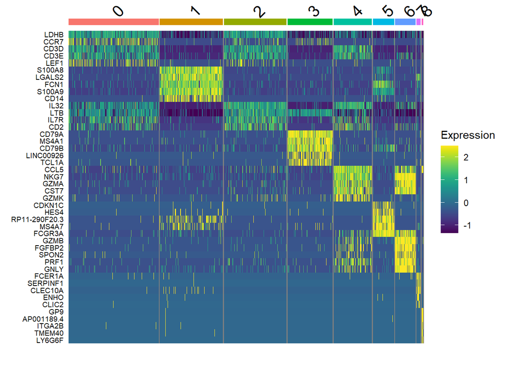

```r
DoHeatmap(pbmc.obj, features = top5$gene) + scale_fill_viridis() +
  theme(axis.text.y = element_text(size = 7, colour = "black")) +
   guides(color = FALSE, fill = guide_colorbar(title = "Expression"))
```

#Assigning cell type identity to clusters

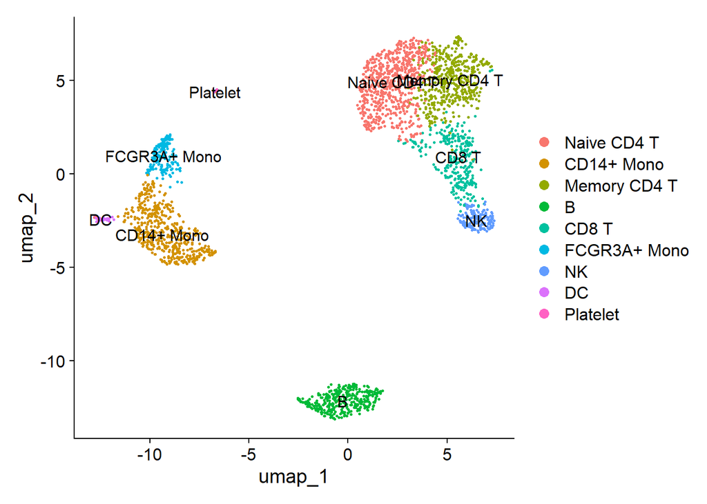

```r
new.cluster.ids <- c("Naive CD4 T", "CD14+ Mono", "Memory CD4 T", "B", "CD8 T", "FCGR3A+ Mono",
    "NK", "DC", "Platelet")
names(new.cluster.ids) <- levels(pbmc.obj)
pbmc.obj <- RenameIdents(pbmc.obj, new.cluster.ids)
DimPlot(pbmc.obj, reduction = "umap", label = TRUE, pt.size = 0.5)
```